# HMWK3

# Prepared by Derek Chen, Justin Zipkin

### load data

```r
library("dplyr")
```

```r
library("ggplot2")
bike=read.csv("citibike.csv")
```

### The citibike management is trying to understand their traffic patters. They have hired you to answer a few basic questions based on the data. You are asked to help CitiBike management by calculating relevant numbers and more importantly, building relevant charts.

### 1. How are male and female ridership patterns different? Do they have different ride duration? Do they have different ride length (distance)?

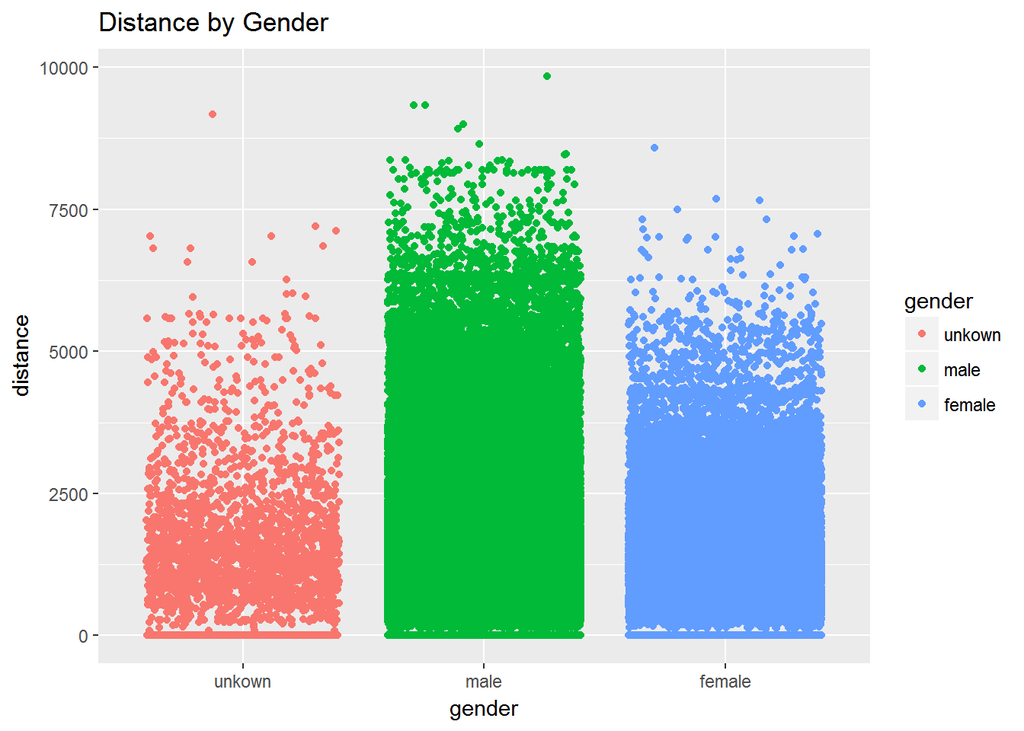

```r
library(geosphere)#for calculating distance
bike$distance <- distHaversine(bike[ ,c("start.station.longitude", "start.station.latitude")],bike[ ,c("end.station.longitude", "end.station.latitude")])
bike$gender=factor(bike$gender,levels=c(0,1,2),labels=c("unkown","male","female"))

ggplot(data = bike, aes(x=gender,y=distance,color=gender))+geom_jitter()+ggtitle("Distance by Gender")
```

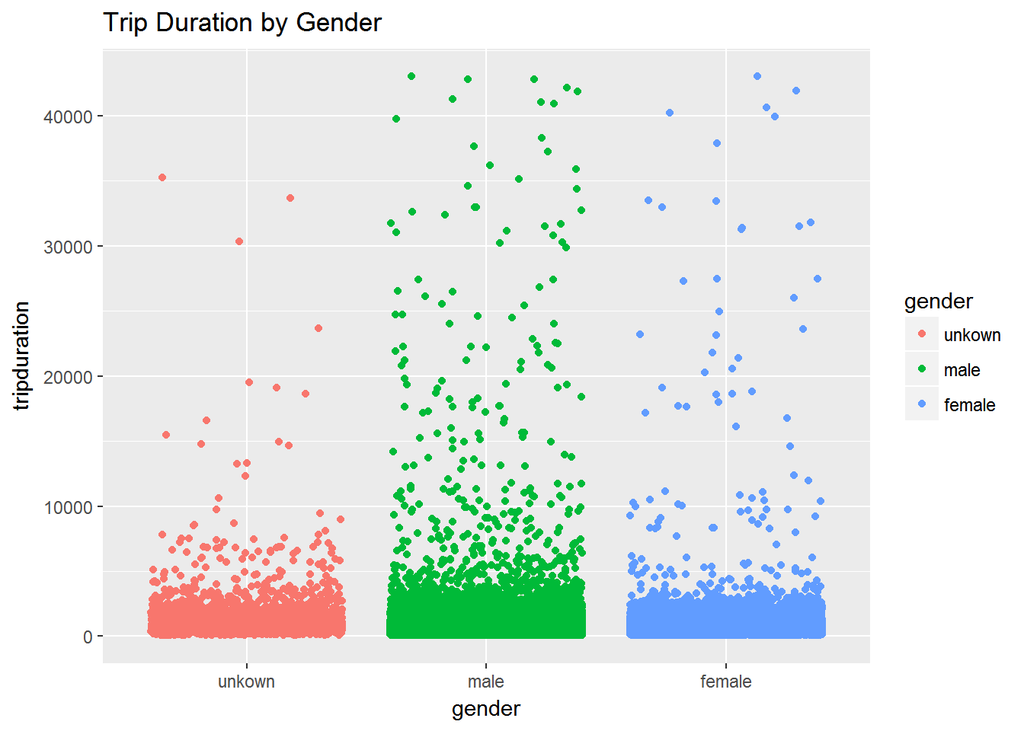

```r
ggplot(data = bike, aes(x=gender,y=tripduration,color=gender))+geom_jitter()+ggtitle("Trip Duration by Gender")
```

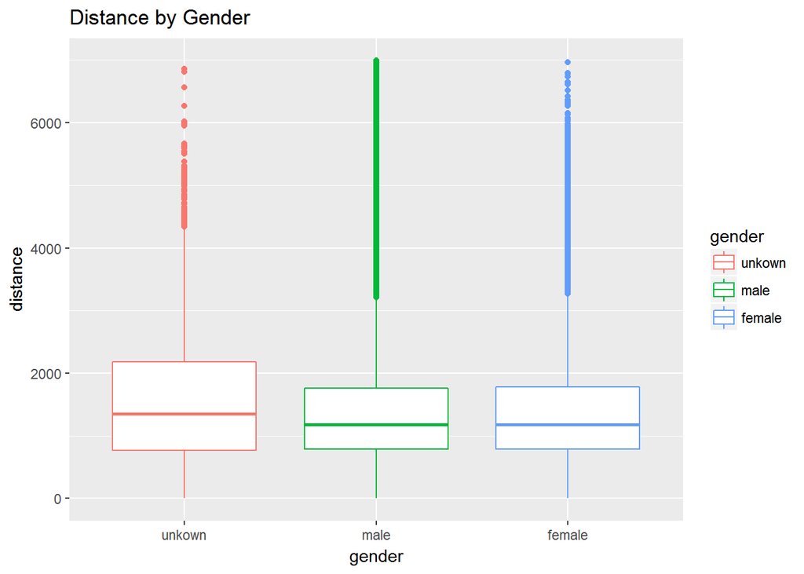

```r
ggplot(data = bike, aes(x=gender,y=distance,color=gender))+geom_boxplot()+ggtitle("Distance by Gender")+ylim(-10,7000)
```

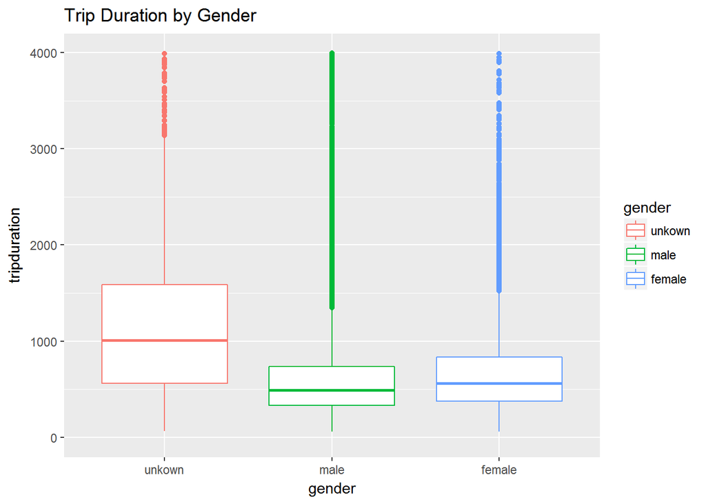

```r
ggplot(data = bike, aes(x=gender,y=tripduration,color=gender))+geom_boxplot()+ggtitle("Trip Duration by Gender")+ylim(-10,4000)
```

### 2. How does the overall level of traffic in the system changes with time of the day and day of the week? Is traffic pattern different during weekdays and weekends (Sat + Sun)?

```r
bike$start.time.of.day=factor(format(strptime(bike$starttime,format = "%m/%d/%Y %H:%M"),"%H"))
bike$end.time.of.day=factor(format(strptime(bike$stoptime,format = "%m/%d/%Y %H:%M"),"%H"))
bike$day.of.week=factor(weekdays(strptime(bike$stoptime,format = "%m/%d/%Y %H:%M")),levels=c("Monday","Tuesday","Wednesday","Thursday","Friday","Saturday","Sunday"),labels=c("Mon","Tues","Wed","Thurs","Fri","Sat","Sun"))
```

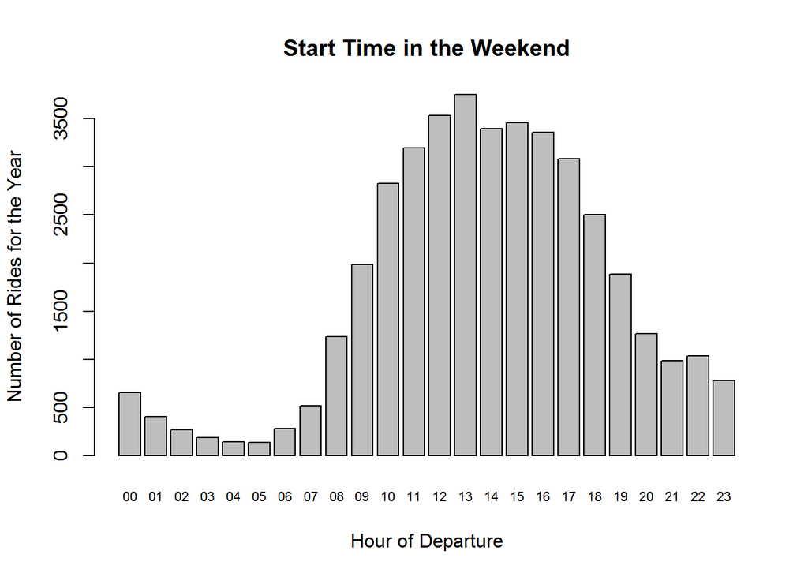

```r
barplot(table(filter(bike,day.of.week=="Sun"|day.of.week=="Sat")$start.time.of.day),main = "Start Time in the Weekend",ylab="Number of Rides for the Year", xlab="Hour of Departure",cex.names  = 0.7)
```

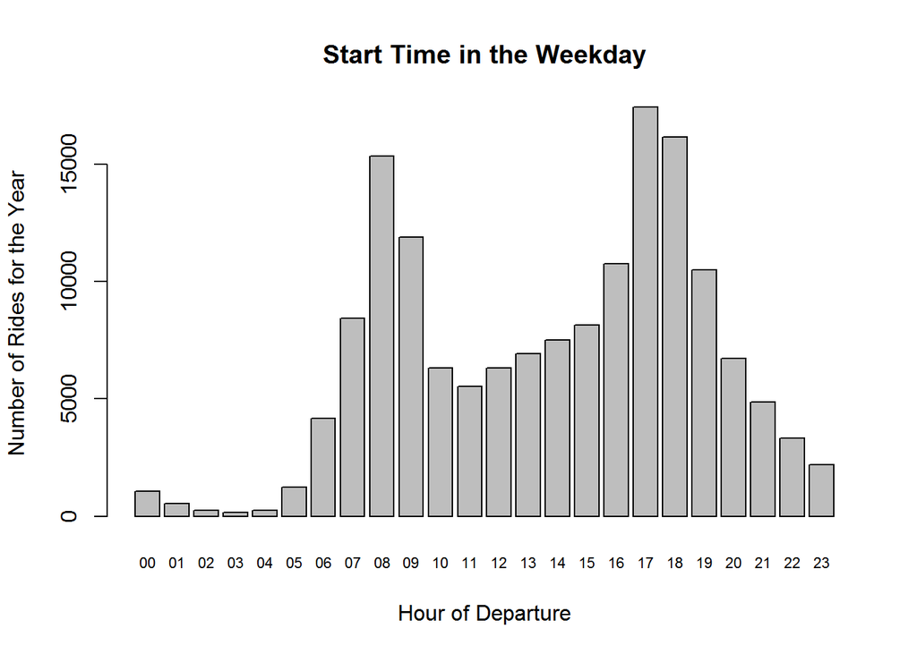

```r
barplot(table(filter(bike,day.of.week!="Sun"& day.of.week!="Sat")$start.time.of.day),main = "Start Time in the Weekday",ylab="Number of Rides for the Year", xlab="Hour of Departure",cex.names  = 0.7)
```

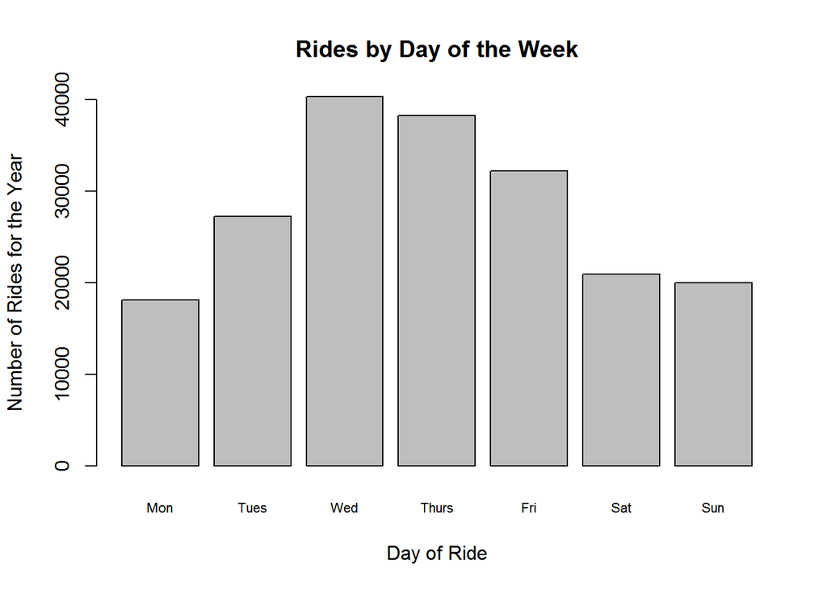

```r
barplot(table(bike$day.of.week),main = "Rides by Day of the Week",ylab="Number of Rides for the Year", xlab="Day of Ride",cex.names  = 0.7)
```

#####The ride distribution is unimodal during the weekend and bimodal during the weekdays. This is because during the weekdays, people are using the bikes as a way to commute to and from work, thus there are two usage peaks around 8 in the morning and 6 in the afternoon. During the weekend, the rides are peaked at around 1 in the afternoon, this might corresponds to more people choose to go out in the afternoons of the weekends. #####Wednesday also seems to have the most number of rides than the rest of the week, with Monday having the lowest level of rides. This might be summarized as “during the weekdays, the closer it is to the weekends, the lesslikely you will ride a citi bike.” My hypothesis is that people are most likely to take a train or taxi in Monday morning because they are still recovering from the weekends’ activities.

### 3. Which stations are most popular (number of rides per minute) at different times of the day?

```r
print(sort(table(bike$start.station.name), decreasing=TRUE)[1:10])
```

```
##
##          8 Ave & W 31 St          W 21 St & 6 Ave    Lafayette St & E 8 St
##                     2238                     2143                     2130
## E 43 St & Vanderbilt Ave          W 41 St & 8 Ave       E 17 St & Broadway
##                     2102                     2078                     1908
##          8 Ave & W 33 St          W 31 St & 7 Ave  Lexington Ave & E 24 St
##                     1901                     1856                     1658
##    Pershing Square South
##                     1624
```

##### The most popular stations to start a ride, overall regardless of time, is the 8th Avenue and 31 Street station. This makes sense because it is the downtown Manhattan, with a lot of businesses and offices surrounding it.

```r
mornings.start=filter(bike,as.numeric(start.time.of.day)>=7,as.numeric(start.time.of.day)<=11)
evenings.start=filter(bike,as.numeric(start.time.of.day)>=18,as.numeric(start.time.of.day)<=22)
middays.start=filter(bike,as.numeric(start.time.of.day)>=12,as.numeric(start.time.of.day)<=16)

mornings.end=filter(bike,as.numeric(end.time.of.day)>=7,as.numeric(end.time.of.day)<=11)
evenings.end=filter(bike,as.numeric(end.time.of.day)>=18,as.numeric(end.time.of.day)<=22)
middays.end=filter(bike,as.numeric(end.time.of.day)>=12,as.numeric(end.time.of.day)<=16)

sort(table(filter(mornings.start,day.of.week!="Sun"& day.of.week!="Sat")$start.station.name), decreasing=TRUE)[1:10]/(5*60)
```

```
##
##          8 Ave & W 31 St          W 41 St & 8 Ave          W 31 St & 7 Ave
##                 4.633333                 3.770000                 2.723333
##          8 Ave & W 33 St    Pershing Square South    Pershing Square North
##                 2.593333                 2.440000                 1.980000
## E 43 St & Vanderbilt Ave       E 10 St & Avenue A          W 33 St & 7 Ave
##                 1.863333                 1.730000                 1.623333
##       E 14 St & Avenue B
##                 1.610000
```

```r
sort(table(filter(mornings.end,day.of.week!="Sun"& day.of.week!="Sat")$end.station.name), decreasing=TRUE)[1:10]/(5*60)
```

```
##
##    Lafayette St & E 8 St     E 24 St & Park Ave S       E 47 St & Park Ave
##                 2.380000                 2.343333                 1.960000
## E 43 St & Vanderbilt Ave          W 51 St & 6 Ave          E 27 St & 1 Ave
##                 1.900000                 1.833333                 1.733333
##       E 17 St & Broadway          W 21 St & 6 Ave       Broadway & E 22 St
##                 1.656667                 1.640000                 1.480000
##       E 32 St & Park Ave
##                 1.396667
```

##### The busiest renting and returning stations are very different, which implies the citi bike operator might need trucks to move bikes between these two stations in order to balance the supply and demand for bikes

```r
sort(table(filter(evenings.start,day.of.week!="Sun"& day.of.week!="Sat")$start.station.name), decreasing=TRUE)[1:10]/(5*60)
```

```
##
## E 43 St & Vanderbilt Ave    Lafayette St & E 8 St       E 17 St & Broadway
##                 3.210000                 2.360000                 2.190000
##          W 21 St & 6 Ave       Broadway & E 22 St  Lexington Ave & E 24 St
##                 2.056667                 2.033333                 1.943333
##    Pershing Square South          W 31 St & 7 Ave    Pershing Square North
##                 1.790000                 1.736667                 1.663333
##     E 24 St & Park Ave S
##                 1.653333
```

```r
sort(table(filter(evenings.end,day.of.week!="Sun"& day.of.week!="Sat")$end.station.name), decreasing=TRUE)[1:10]/(5*60)
```

```
##
##          W 41 St & 8 Ave          W 33 St & 7 Ave E 43 St & Vanderbilt Ave
##                 4.206667                 3.413333                 3.230000
##          8 Ave & W 31 St          W 31 St & 7 Ave          8 Ave & W 33 St
##                 2.880000                 2.813333                 2.580000
##    Pershing Square South    Pershing Square North  Lexington Ave & E 24 St
##                 1.966667                 1.890000                 1.800000
##          1 Ave & E 15 St
##                 1.730000
```

##### Similar to the trend observed above, the busiest renting station list is very different from the busiest returning station list. The citi bike operator is likely to have to move bikes to balance the supply and demand

```r
sort(table(filter(middays.start,day.of.week=="Sun"| day.of.week=="Sat")$start.station.name), decreasing=TRUE)[1:10]/(5*60)
```

```
##
##         W 21 St & 6 Ave      E 17 St & Broadway   Lafayette St & E 8 St
##               0.9033333               0.7466667               0.6733333
##   Greenwich Ave & 8 Ave University Pl & E 14 St      E 10 St & Avenue A
##               0.6233333               0.5866667               0.5633333
##         2 Ave & E 31 St         9 Ave & W 22 St      Broadway & E 14 St
##               0.5266667               0.5266667               0.5266667
## Lexington Ave & E 24 St
##               0.5033333
```

```r
sort(table(filter(middays.end,day.of.week=="Sun"| day.of.week=="Sat")$end.station.name), decreasing=TRUE)[1:10]/(5*60)
```

```
##
##          W 21 St & 6 Ave       E 17 St & Broadway    Lafayette St & E 8 St
##                0.9200000                0.8333333                0.7400000
##  University Pl & E 14 St       Broadway & E 14 St          W 18 St & 6 Ave
##                0.6533333                0.5933333                0.5800000
##    Greenwich Ave & 8 Ave          9 Ave & W 22 St         W 20 St & 11 Ave
##                0.5666667                0.5600000                0.5566667
## Lafayette St & Jersey St
##                0.5233333
```

##### During the weekends, the busiest renting and returning station lists are almost identical. This implies that during the weekends, most stations will have a balanced supply and demand for bikes, because there is an equal amount of people renting out and returning bikes. Thus the operator is less likely to have to move bikes between stations.

### 4. Last but most important - can you think of a good question to ask (and provide data/charts in answer) that will provide the CitiBike management with a better view of their ridership or traffic patterns?

##### Here I want to find a linear relationship between age, gender, interaction between age and gender, and the the ride duration and ride distance

```r
mo=lm(tripduration~birth.year+gender+birth.year*gender,data = bike)
summary(mo)
```

```
##
## Call:
## lm(formula = tripduration ~ birth.year + gender + birth.year *
##     gender, data = bike)
##
## Residuals:
##    Min     1Q Median     3Q    Max
##   -860   -296   -132    117  42312
##
## Coefficients:
##                          Estimate Std. Error t value Pr(>|t|)
## (Intercept)             -23640.86   95884.16  -0.247    0.805
## birth.year                  12.07      48.13   0.251    0.802
## gendermale               32072.59   95884.81   0.334    0.738
## genderfemale             29514.87   95887.44   0.308    0.758
## birth.year:gendermale      -16.02      48.13  -0.333    0.739
## birth.year:genderfemale    -14.68      48.13  -0.305    0.760
##
## Residual standard error: 844.6 on 194657 degrees of freedom
##   (2267 observations deleted due to missingness)
## Multiple R-squared:  0.004289,   Adjusted R-squared:  0.004264
## F-statistic: 167.7 on 5 and 194657 DF,  p-value: < 2.2e-16
```

##### The very large P value suggests that these coefficients are not very good predictor of the riding duration

```r
mo2=lm(distance~birth.year+gender+birth.year*gender,data = bike)
summary(mo2)
```

```
##
## Call:
## lm(formula = distance ~ birth.year + gender + birth.year * gender,
##     data = bike)
##
## Residuals:
##     Min      1Q  Median      3Q     Max
## -1617.0  -635.9  -245.4   340.5  8425.6
##
## Coefficients:
##                          Estimate Std. Error t value Pr(>|t|)
## (Intercept)             -49063.86  111226.81  -0.441    0.659
## birth.year                  25.05      55.84   0.449    0.654
## gendermale               55476.51  111227.56   0.499    0.618
## genderfemale             49458.84  111230.61   0.445    0.657
## birth.year:gendermale      -27.58      55.84  -0.494    0.621
## birth.year:genderfemale    -24.54      55.84  -0.439    0.660
##
## Residual standard error: 979.7 on 194657 degrees of freedom
##   (2267 observations deleted due to missingness)
## Multiple R-squared:  0.0008839,  Adjusted R-squared:  0.0008582
## F-statistic: 34.44 on 5 and 194657 DF,  p-value: < 2.2e-16
```

##### The very large P value also suggests that these coefficients are not very good predictor of the riding distance. Thus more user information might be needed to predict the ride duration and ride distance

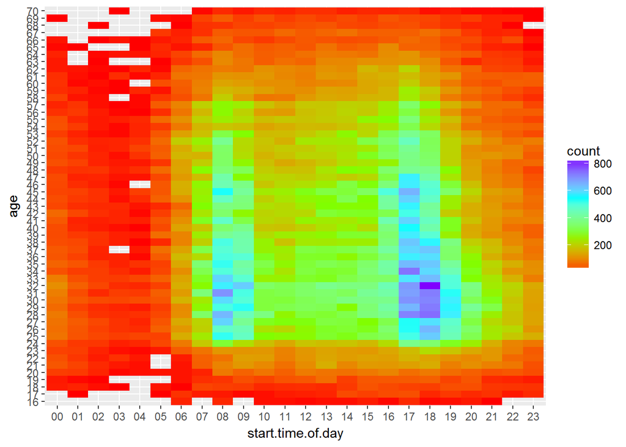

```r
bike$age=factor(2015-bike$birth.year)
bike$ageint=2015-bike$birth.year
ggplot(data = filter(bike,ageint<=70),aes(x=start.time.of.day,y=age))+geom_bin2d()+ scale_fill_gradientn(colours=rainbow(4))
```